# Generate figures in Ablation Analysis

Ningshan Li

2024/05/09

# 1 Summary

This R Notebook generates figures in **Ablation Analysis** section in manuscript.

We performed ablation test on 4 components: **pseudo-spots in training CVAE**, **sparsity penalty**, **spatial correlation constraint** and **platform effect removal**.

We performed ablation test on 3 datasets: [**STARmap-based** simulated dataset](https://rawcdn.githack.com/az7jh2/SDePER_Analysis/c60dcb036816bd61b5a8b3752d473a5b591b52b6/Simulation/Generate_simulation_data/generate_simulated_spatial_data.nb.html), [**sequencing-based** simulated dataset](https://rawcdn.githack.com/az7jh2/SDePER_Analysis/03f921545a4e5d5a8fab813658eb2d9953f84cc7/Simulation_seq_based/Generate_simulation_data/generate_simulated_spatial_data.nb.html) and [**high density sequencing-based** simulated dataset](https://rawcdn.githack.com/az7jh2/SDePER_Analysis/d22e0c9b4574530a8ecbdf620638f2527ec20c5e/Simulation_seq_based/Generate_high_density_simulation_data/generate_simulated_spatial_data.nb.html).

To evaluate the impact of adaptive Lasso on datasets with fewer cell types, we also performed ablation test on **sparsity penalty** on [STARmap-based simulated dataset with a subset of 5 cell types](https://rawcdn.githack.com/az7jh2/SDePER_Analysis/ab7b78abe53a4c625b71ce9eb5ab96bf2b829c5c/Simulation/Generate_simulation_data_subsetCT/generate_simulated_spatial_data_subsetCT.nb.html).

1. **Inputs**:
   - [`ablation_all_results.rds`](https://github.com/az7jh2/SDePER_Analysis/blob/main/Ablation/ablation_all_results.rds): cell type deconvolution results of all ablation test on SDePER, as well as the ground truth in Ablation analysis.
2. **Outputs**:
   - Figure. Boxplot of performance of all ablation test on SDePER on simulated data

# 2 Version

```r
version[['version.string']]
```

```
[1] "R version 4.2.2 Patched (2022-11-10 r83330)"
```

```r
print(sprintf('Package %s version: %s', 'ggplot2', packageVersion('ggplot2')))
```

```
[1] "Package ggplot2 version: 3.4.2"
```

```r
print(sprintf('Package %s version: %s', 'ggpubr', packageVersion('ggpubr')))
```

```
[1] "Package ggpubr version: 0.6.0"
```

```r
print(sprintf('Package %s version: %s', 'philentropy', packageVersion('philentropy'))) # JSD function
```

```
[1] "Package philentropy version: 0.7.0"
```

# 3 Read relevant files

## 3.1 Read estimated cell type proportions in ablation test

```r
file_name = file.path(home.dir, 'ablation_all_results.rds')
all_res = readRDS(file_name)
print(sprintf('load data from %s', file_name))
```

```
[1] "load data from /home/hill103/Documents/Spatial/Ablation/ablation_all_results.rds"
```

Check the order of spots and cell types are consistent before performance evaluation.

```r
for (dataset in names(all_res)) {
  for (scenario in names(all_res[[dataset]])) {
    if (scenario != 'Truth') {
      for (method_name in names(all_res[[dataset]][[scenario]])) {
        stopifnot(all(row.names(all_res[[dataset]][[scenario]][[method_name]]) == row.names(all_res[[dataset]][['Truth']])))
        stopifnot(all(colnames(all_res[[dataset]][[scenario]][[method_name]]) == colnames(all_res[[dataset]][['Truth']])))
      }
    }
  }
}
```

Check whether negative values of estimated cell type proportions exist, as negative values may cause error in JSD calculation and got `NaN`. Replace them as 0.

```r
for (dataset in names(all_res)) {
  for (scenario in names(all_res[[dataset]])) {
    if (scenario != 'Truth') {
      for (method_name in names(all_res[[dataset]][[scenario]])) {
        tmp_df = all_res[[dataset]][[scenario]][[method_name]]
        for (i in 1:nrow(tmp_df)) {
          for (j in 1:ncol(tmp_df)) {
            if (tmp_df[i, j] < 0) {
              print(sprintf('%s - %s: %s result: row %d (%s) column %d (%s) has negative value %g', dataset, scenario, method_name, i, row.names(tmp_df)[i], j, colnames(tmp_df)[j], tmp_df[i, j]))
              # replace them with 0
              all_res[[dataset]][[scenario]][[method_name]][i, j] = 0
            }
          }
        }
      }
    }
  }
}
```

# 4 Evaluate performance of cell type deconvolution methods

## 4.1 Calculate spot-wise performance of all methods

5 performance measurements:

- root mean square error (**RMSE**): quantifies the overall estimation accuracy
- Jensen-Shannon Divergence (**JSD**): assesses similarity between the estimated cell type distribution and ground-truth per spot
- **Pearson’s correlation coefficient**: measures the similarity of estimation to ground-truth
- false discovery rate (**FDR**): measures how many cell types were falsely predicted to be present
- false negative rate (**FNR**): measures how many presented cell types were falsely predicted to be not present

```r
binaryPredEvaluation = function(truth, pred) {
  # Given an array of truth and predictions (either 0 or 1), calculate confusion matrix
  # convert to factors to ensure get a full 2*2 confusion matrix
  truth_factor = factor(truth, levels = c(0, 1))
  pred_factor = factor(pred, levels = c(0, 1))
  # Generate confusion matrix
  conf_matrix = table(Actual = truth_factor, Predicted = pred_factor)
  # Extract elements of the confusion matrix
  TP = conf_matrix[2, 2]
  FP = conf_matrix[1, 2]
  FN = conf_matrix[2, 1]
  TN = conf_matrix[1, 1]
  # Calculate FDR (False Discovery Rate)
  FDR = FP / (TP + FP)
  # Calculate FNR (False Negative Rate)
  FNR = FN / (TP + FN)
  return(c(FDR, FNR))
}

calcPerformance = function(truth, pred) {
  # calculate RMSE, JSD, correlation and FDR for each row
  # inputs are matrix with rows as spots and columns as cell types, order has been checked to be consistent
  stopifnot(all(row.names(truth) == row.names(pred)))
  stopifnot(all(colnames(truth) == colnames(pred)))

  # binary cell type proportions (0:absent; 1:present)
  truth_binary = truth != 0
  pred_binary = pred != 0
  # in-place conversion from bool to 0/1 while keeping dimensions, row names and column names, as `as.numeric()` will "flattern" the original matrix
  truth_binary[] = as.numeric(truth_binary)
  pred_binary[] = as.numeric(pred_binary)

  perform_df = data.frame(matrix(ncol=5, nrow=0))
  colnames(perform_df) = c('RMSE', 'JSD', 'Pearson', 'FDR', 'FNR')

  for (i in 1:nrow(truth)) {
    RMSE = sqrt(mean((truth[i,] - pred[i,]) ^ 2))
    if (sum(pred[i,])>0 & sum(truth[i,])>0) {
      JSD = philentropy::JSD(rbind(truth[i,], pred[i,]), unit = 'log2', est.prob = 'empirical')
    } else {
      JSD = 1
    }
    Pearson = cor.test(truth[i,], pred[i,])$estimate
    tmp = binaryPredEvaluation(truth_binary[i,], pred_binary[i,])
    FDR = tmp[1]
    FNR = tmp[2]

    perform_df[nrow(perform_df)+1, ] = c(RMSE, JSD, Pearson, FDR, FNR)
  }

  # also record spot names
  stopifnot(nrow(perform_df) == nrow(truth))
  perform_df['Spot'] = row.names(truth)

  return(perform_df)
}


all_perform = list()

for (dataset in names(all_res)) {
  all_perform[[dataset]] = list()
  for (scenario in names(all_res[[dataset]])) {
    if (scenario != 'Truth') {
      all_perform[[dataset]][[scenario]] = list()
      for (method_name in names(all_res[[dataset]][[scenario]])) {
        all_perform[[dataset]][[scenario]][[method_name]] = calcPerformance(as.matrix(all_res[[dataset]][['Truth']]), as.matrix(all_res[[dataset]][[scenario]][[method_name]]))
      }
    }
  }
}
```

## 4.2 Summary spot-wise performance into method-wise

```r
perform_raw_df = data.frame(matrix(ncol=11, nrow=0))
colnames(perform_raw_df) = c('Dataset', 'Density', 'Scenario', 'Method', 'Reference', 'Spot', 'RMSE', 'JSD', 'Pearson', 'FDR', 'FNR')

# calculate median performance across all spatial spots for all methods
perform_median_df = data.frame(matrix(ncol=10, nrow=0))
colnames(perform_median_df) = c('Dataset', 'Density', 'Scenario', 'Method', 'Reference', 'median_RMSE', 'median_JSD', 'median_Pearson', 'median_FDR', 'median_FNR')

for (dataset in names(all_perform)) {
  if (dataset == "Simulation") {
    this_dataset = 'STARmap-based'
    this_density = '1x'
  } else if (dataset == "Simulation_seq_based") {
    this_dataset = 'seq-based'
    this_density = '1x'
  } else if (dataset == "Simulation_seq_based_3x") {
    this_dataset = 'seq-based'
    this_density = '3x'
  } else if (dataset == "Simulation_seq_based_6x") {
    this_dataset = 'seq-based'
    this_density = '6x'
  } else if (dataset == 'Simulation_subsetCT') {
    this_dataset = 'STARmap-based'
    this_density = 'subsetCT'
  } else {
    stop('unknown dataset')
  }

  for (scenario in names(all_perform[[dataset]])) {
    if (scenario == "S1_int_ref") {
      this_scenario = 'Scenario 1'
      this_ref = 'Internal'
    } else if (scenario == "S1_ext_ref") {
      this_scenario = 'Scenario 1'
      this_ref = 'External'
    } else if (scenario == 'S2_ext_ref') {
      this_scenario = 'Scenario 2'
      this_ref = 'External'
    } else if (scenario == 'S3_ext_ref') {
      this_scenario = 'Scenario 3'
      this_ref = 'External'
    } else {
      stop('unknown scenario')
    }

    for (method_name in names(all_perform[[dataset]][[scenario]])) {
      tmp_df = all_perform[[dataset]][[scenario]][[method_name]]
      tmp_df['Dataset'] = this_dataset
      tmp_df['Density'] = this_density
      tmp_df['Scenario'] = this_scenario
      tmp_df['Method'] = method_name
      tmp_df['Reference'] = this_ref

      perform_raw_df = rbind(perform_raw_df, tmp_df[, c('Dataset', 'Density', 'Scenario', 'Method', 'Reference', 'Spot', 'RMSE', 'JSD', 'Pearson', 'FDR', 'FNR')])

      perform_median_df[nrow(perform_median_df)+1, ] = c(this_dataset, this_density, this_scenario, method_name, this_ref,
                                                       round(median(tmp_df$RMSE), 3),
                                                       round(median(tmp_df$JSD), 3),
                                                       round(median(tmp_df$Pearson), 3),
                                                       round(median(tmp_df$FDR), 3),
                                                       round(median(tmp_df$FNR), 3))

    }
  }
}

# set method column as factors
perform_raw_df['Method'] = factor(perform_raw_df$Method, levels = c("SDePER", "NO_PlatEffRmv", "NO_pseudo_spots", "NO_LASSO", "NO_Laplacian"))


perform_raw_df = perform_raw_df %>%
  filter(Method %in% c("SDePER", "NO_PlatEffRmv", "NO_pseudo_spots", "NO_LASSO", "NO_Laplacian"))

perform_median_df = perform_median_df %>%
  filter(Method %in% c("SDePER", "NO_PlatEffRmv", "NO_pseudo_spots", "NO_LASSO", "NO_Laplacian"))

perform_median_df[, c('Dataset', 'Density', 'Scenario', 'Method', 'Reference', 'median_RMSE', 'median_JSD', 'median_Pearson', 'median_FDR', 'median_FNR')]
```

| Dataset | Density | Scenario | Method | Reference | median_RMSE | median_JSD | median_Pearson | median_FDR | median_FNR |
| --- | --- | --- | --- | --- | --- | --- | --- | --- | --- |
| STARmap-based | 1x | Scenario 1 | SDePER | Internal | 0.101 | 0.179 | 0.892 | 0.5 | 0.25 |
| STARmap-based | 1x | Scenario 1 | NO_pseudo_spots | Internal | 0.107 | 0.15 | 0.904 | 0 | 0 |
| STARmap-based | 1x | Scenario 1 | NO_LASSO | Internal | 0.101 | 0.179 | 0.884 | 0.5 | 0 |
| STARmap-based | 1x | Scenario 1 | NO_Laplacian | Internal | 0.111 | 0.191 | 0.87 | 0.5 | 0.333 |
| STARmap-based | 1x | Scenario 1 | NO_PlatEffRmv | Internal | 0.066 | 0.095 | 0.946 | 0.5 | 0 |
| STARmap-based | 1x | Scenario 1 | SDePER | External | 0.12 | 0.274 | 0.819 | 0.667 | 0 |
| STARmap-based | 1x | Scenario 1 | NO_pseudo_spots | External | 0.155 | 0.368 | 0.683 | 0.667 | 0.333 |
| STARmap-based | 1x | Scenario 1 | NO_LASSO | External | 0.12 | 0.271 | 0.822 | 0.714 | 0 |
| STARmap-based | 1x | Scenario 1 | NO_Laplacian | External | 0.121 | 0.27 | 0.82 | 0.714 | 0 |
| STARmap-based | 1x | Scenario 1 | NO_PlatEffRmv | External | 0.187 | 0.535 | 0.413 | 0.818 | 0 |

[output cut: 34 more lines]

# 5 Ablation test for STARmap-based simulation data

## 5.1 Figure. Boxplot of performance of all methods in Ablation test on Simulated Data Scenario 1

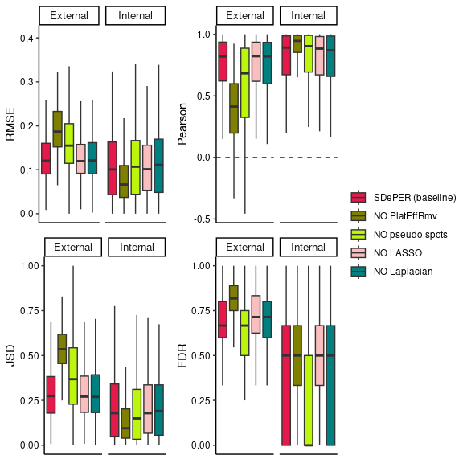

```r
if (save_file) {
  file_name = file.path(home.dir, 'Fig_ablation_simulation_S1_performance.pdf')
  cairo_pdf(file_name, height=6, width=6, onefile=T)
  print(sprintf('figures saved in file %s', file_name))
}

plot_df = perform_raw_df %>%
  filter(Dataset=='STARmap-based' & Density=='1x' & Scenario=='Scenario 1')

g_list = list()

for (perform_ind in c('RMSE', 'Pearson', 'JSD', 'FDR')) {
  g_list[[perform_ind]] = ggplot(plot_df, aes(x=Method, y=.data[[perform_ind]], fill=Method)) +
                            geom_boxplot(position=position_dodge(), outlier.shape=NA) +
                            scale_fill_manual(values=method_color, labels=c('SDePER'='SDePER (baseline)','GLRM'='GLRM (NO CVAE)', 'NO_PlatEffRmv'='NO PlatEffRmv', 'NO_pseudo_spots'='NO pseudo spots', 'NO_LASSO'='NO LASSO', 'NO_Laplacian'='NO Laplacian', 'NO_LASSO_Laplacian'='NO LASSO Laplacian', 'NO_CVAE_LASSO_Laplacian'='NO CVAE LASSO Laplacian', 'NO_PlatEffRmv_LASSO_Laplacian'='NO PlatEffRmv LASSO Laplacian')) +
                            theme_classic() +
                            theme(strip.text = element_text(size=10),
                                  axis.text = element_text(color="black"),
                                  axis.ticks.x = element_blank(),
                                  axis.text.x = element_blank(),
                                  axis.title.x = element_blank(),
                                  legend.title = element_blank()) +
                            facet_grid(~Reference)

}

g_list[['Pearson']] = g_list[['Pearson']] + geom_hline(yintercept=0, color="red", linetype="dashed")

ggpubr::ggarrange(plotlist=g_list, ncol=2, nrow=2, common.legend=TRUE, legend="right")
```

## 5.2 Addtional boxplot for FNR

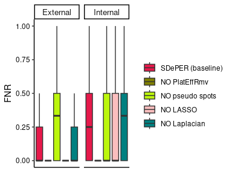

```r
ggplot(plot_df, aes(x=Method, y=FNR, fill=Method)) +
  geom_boxplot(position=position_dodge(), outlier.shape=NA) +
  scale_fill_manual(values=method_color, labels=c('SDePER'='SDePER (baseline)','GLRM'='GLRM (NO CVAE)', 'NO_PlatEffRmv'='NO PlatEffRmv', 'NO_pseudo_spots'='NO pseudo spots', 'NO_LASSO'='NO LASSO', 'NO_Laplacian'='NO Laplacian', 'NO_LASSO_Laplacian'='NO LASSO Laplacian', 'NO_CVAE_LASSO_Laplacian'='NO CVAE LASSO Laplacian', 'NO_PlatEffRmv_LASSO_Laplacian'='NO PlatEffRmv LASSO Laplacian')) +
  theme_classic() +
  theme(strip.text = element_text(size=10),
        axis.text = element_text(color="black"),
        axis.ticks.x = element_blank(),
        axis.text.x = element_blank(),
        axis.title.x = element_blank(),
        legend.title = element_blank()) +
        facet_grid(~Reference)
```

# 6 Ablation test for Sequencing-based simulation data

## 6.1 Figure. Boxplot of performance of all methods in Ablation test on Simulated Data Scenario 1

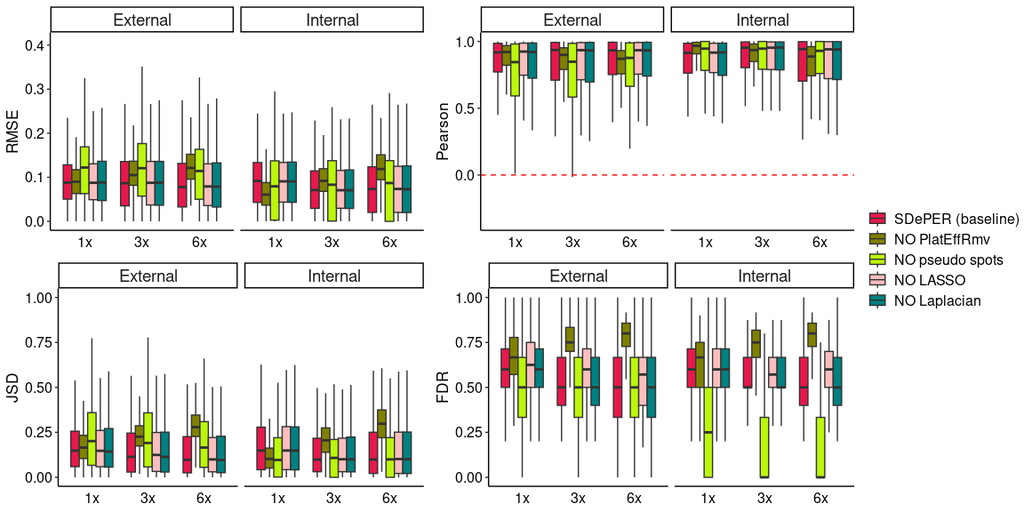

```r
if (save_file) {
  file_name = file.path(home.dir, 'Fig_ablation_simulation_seq_based_S1_performance.pdf')
  cairo_pdf(file_name, height=6, width=12, onefile=T)
  print(sprintf('figures saved in file %s', file_name))
}

plot_df = perform_raw_df %>%
  filter(Dataset=='seq-based' & Scenario=='Scenario 1')

g_list = list()

for (perform_ind in c('RMSE', 'Pearson', 'JSD', 'FDR')) {
  g_list[[perform_ind]] = ggplot(plot_df, aes(x=Density, y=.data[[perform_ind]], fill=Method)) +
                            geom_boxplot(position=position_dodge(), outlier.shape=NA) +
                            scale_fill_manual(values=method_color, labels=c('SDePER'='SDePER (baseline)','GLRM'='GLRM (NO CVAE)', 'NO_PlatEffRmv'='NO PlatEffRmv', 'NO_pseudo_spots'='NO pseudo spots', 'NO_LASSO'='NO LASSO', 'NO_Laplacian'='NO Laplacian', 'NO_LASSO_Laplacian'='NO LASSO Laplacian', 'NO_CVAE_LASSO_Laplacian'='NO CVAE LASSO Laplacian', 'NO_PlatEffRmv_LASSO_Laplacian'='NO PlatEffRmv LASSO Laplacian')) +
                            theme_classic() +
                            theme(strip.text = element_text(size=14),
                                  axis.text = element_text(color="black", size=12),
                                  axis.ticks.x = element_blank(),
                                  axis.text.x = element_text(color="black", size=12),
                                  axis.title.x = element_blank(),
                                  axis.title.y = element_text(size=13),
                                  legend.title = element_blank(),
                                  legend.text = element_text(size=12)) +
                            facet_grid(~Reference)

}

g_list[['Pearson']] = g_list[['Pearson']] + geom_hline(yintercept=0, color="red", linetype="dashed")

ggpubr::ggarrange(plotlist=g_list, ncol=2, nrow=2, common.legend=TRUE, legend="right")
```

## 6.2 Addtional boxplot for FNR

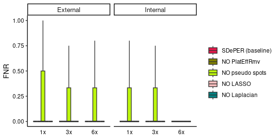

```r
ggplot(plot_df, aes(x=Density, y=FNR, fill=Method)) +
  geom_boxplot(position=position_dodge(), outlier.shape=NA) +
  scale_fill_manual(values=method_color, labels=c('SDePER'='SDePER (baseline)','GLRM'='GLRM (NO CVAE)', 'NO_PlatEffRmv'='NO PlatEffRmv', 'NO_pseudo_spots'='NO pseudo spots', 'NO_LASSO'='NO LASSO', 'NO_Laplacian'='NO Laplacian', 'NO_LASSO_Laplacian'='NO LASSO Laplacian', 'NO_CVAE_LASSO_Laplacian'='NO CVAE LASSO Laplacian', 'NO_PlatEffRmv_LASSO_Laplacian'='NO PlatEffRmv LASSO Laplacian')) +
  theme_classic() +
  theme(strip.text = element_text(size=10),
        axis.text = element_text(color="black"),
        axis.ticks.x = element_blank(),
        axis.text.x = element_text(),
        axis.title.x = element_blank(),
        legend.title = element_blank()) +
        facet_grid(~Reference)
```

# 7 Ablation test for STARmap-based simulation data with subset of cell types

## 7.1 Figure. Boxplot of performance of all methods in Ablation test on Simulated Data Scenario 1

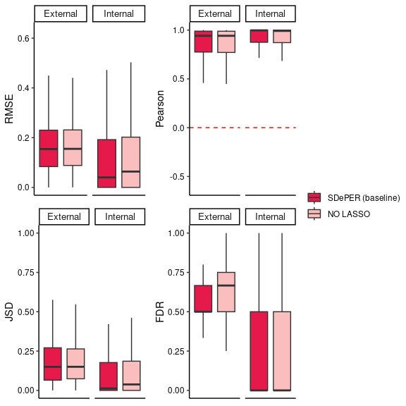

```r
if (save_file) {
  file_name = file.path(home.dir, 'Fig_ablation_simulation_subsetCT_S1_performance.pdf')
  cairo_pdf(file_name, height=6, width=6, onefile=T)
  print(sprintf('figures saved in file %s', file_name))
}

plot_df = perform_raw_df %>%
  filter(Dataset=='STARmap-based' & Density=='subsetCT' & Scenario=='Scenario 1')

g_list = list()

for (perform_ind in c('RMSE', 'Pearson', 'JSD', 'FDR')) {
  g_list[[perform_ind]] = ggplot(plot_df, aes(x=Method, y=.data[[perform_ind]], fill=Method)) +
                            geom_boxplot(position=position_dodge(), outlier.shape=NA) +
                            scale_fill_manual(values=method_color, labels=c('SDePER'='SDePER (baseline)','GLRM'='GLRM (NO CVAE)', 'NO_PlatEffRmv'='NO PlatEffRmv', 'NO_pseudo_spots'='NO pseudo spots', 'NO_LASSO'='NO LASSO', 'NO_Laplacian'='NO Laplacian', 'NO_LASSO_Laplacian'='NO LASSO Laplacian', 'NO_CVAE_LASSO_Laplacian'='NO CVAE LASSO Laplacian', 'NO_PlatEffRmv_LASSO_Laplacian'='NO PlatEffRmv LASSO Laplacian')) +
                            theme_classic() +
                            theme(strip.text = element_text(size=10),
                                  axis.text = element_text(color="black"),
                                  axis.ticks.x = element_blank(),
                                  axis.text.x = element_blank(),
                                  axis.title.x = element_blank(),
                                  legend.title = element_blank()) +
                            facet_grid(~Reference)

}

g_list[['Pearson']] = g_list[['Pearson']] + geom_hline(yintercept=0, color="red", linetype="dashed")

ggpubr::ggarrange(plotlist=g_list, ncol=2, nrow=2, common.legend=TRUE, legend="right")
```

## 7.2 Addtional boxplot for FNR

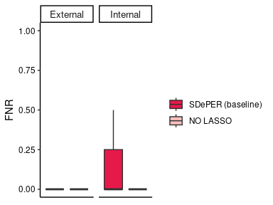

```r
ggplot(plot_df, aes(x=Method, y=FNR, fill=Method)) +
  geom_boxplot(position=position_dodge(), outlier.shape=NA) +
  scale_fill_manual(values=method_color, labels=c('SDePER'='SDePER (baseline)','GLRM'='GLRM (NO CVAE)', 'NO_PlatEffRmv'='NO PlatEffRmv', 'NO_pseudo_spots'='NO pseudo spots', 'NO_LASSO'='NO LASSO', 'NO_Laplacian'='NO Laplacian', 'NO_LASSO_Laplacian'='NO LASSO Laplacian', 'NO_CVAE_LASSO_Laplacian'='NO CVAE LASSO Laplacian', 'NO_PlatEffRmv_LASSO_Laplacian'='NO PlatEffRmv LASSO Laplacian')) +
  theme_classic() +
  theme(strip.text = element_text(size=10),
        axis.text = element_text(color="black"),
        axis.ticks.x = element_blank(),
        axis.text.x = element_blank(),
        axis.title.x = element_blank(),
        legend.title = element_blank()) +
        facet_grid(~Reference)
```